# Assignment 3 Task 2

Sarah Lam

### Overview

This code performs agglomerative hierarchical clustering to analyze and compare water quality at stream sites. The data utilized measures chemical concentrations between sites for Santa Barbara Long Term Ecological Research (LTER). The data has been collected for the Santa Barbara Coastal LTER since 2000 and includes concentrations of NH4, NO3, PO4, dissolved nitrogen, dissolved phosphorous, terephthaloyl chloride, particulate phosphorous, and measurements of turbidity.

Citation: Santa Barbara Coastal LTER and J. Melack. 2019. SBC LTER: Land: Stream chemistry in the Santa Barbara Coastal drainage area, ongoing since 2000 ver 16. Environmental Data Initiative. https://doi.org/10.6073/pasta/67a558a24ceed9a0a5bf5e46ab841174.

```r
#read in the data
stream_chemistry <- read_csv(here("data", "sbc_lter_registered_stream_chemistry.csv")) %>%
  clean_names() %>%
  na_if(-999.0) %>%
  drop_na() %>%
  group_by(site_code)
colnames(stream_chemistry) <- gsub("_u_m", "", colnames(stream_chemistry))

stream_sum <- stream_chemistry %>% #summarize for scale function
  summarize(nh4 = mean(nh4),
            no3 = mean(no3),
            po4 = mean(po4),
            tdn = mean(tdn),
            tdp = mean(tdp),
            tpc = mean(tpc),
            tpp = mean(tpp),
            tss_mgper_liter = mean(tss_mgper_liter),
            spec_cond_u_spercm = mean(spec_cond_u_spercm))

stream_scale <- stream_sum %>%
  select(nh4:spec_cond_u_spercm) %>%
  scale()

rownames(stream_scale) <- stream_sum$site_code #add in site codes as row names
```

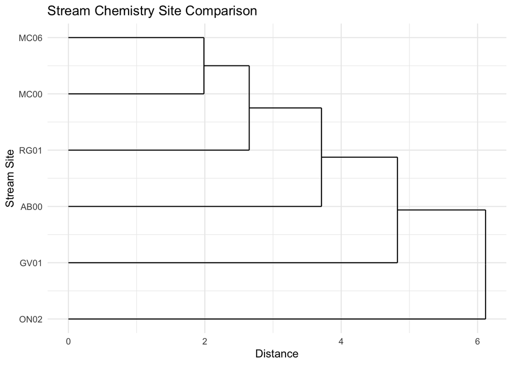

```r
#creating a dendrogram, calculating euclidean distance
stream_dist <- dist(stream_scale, method = 'euclidean', diag = TRUE, upper = TRUE)
   ### also look at upper and diag arguments

# Hierarchical clustering (complete linkage)
stream_hc_complete <- hclust(stream_dist, method = "complete")

# Plot it:
ggdendrogram(stream_hc_complete, rotate = TRUE, color = "darkcyan") +
  theme_minimal() +
  labs(x = "Stream Site",
       y = "Distance",
       title = "Stream Chemistry Site Comparison")
```

**Figure 1.** This figure compares stream chemistry averages across six Santa Barbara Long Term Ecological Research (LTER) sites using hierarchical clustering.

### Summary

- Sites MC06 and MC00 are the most similar sites, while ON02 had the least close in euclidean distance.
- The even distance between each cluster may indicate that none of the sites are significantly closer to to each other and we should use 6 clusters for further analysis.
- Other methods of clustering should be explored to see if another method is better than complete hierarchical.